# Liberia datos climaticos

### Datos sobre el clima de la zona de Liberia

A continuacion se representaran los datos climaticos de Liberia. Aquí se presentan algunos de los datos, que nos fueron proporcionados para la Zona de Liberia

```r
# Eliminar NA
inp <- read.csv("Liberia_datos climaticos.csv",sep = ",",na.strings="",dec = ",")
inp1 <- na.omit(inp)

# Cambio de datos.
inp1$Date <- as.Date(inp1$Date, "%d/%m/%Y")
inp1$Temperatura..Celsius. <- as.numeric(inp1$Temperatura..Celsius.)
inp1$HumedadRelativa....<- as.numeric(inp1$HumedadRelativa....)
inp1$VelocidadViento..m.s.<- as.numeric(inp1$VelocidadViento..m.s.)
inp1$Lluvia..mm.<- as.numeric(inp1$Lluvia..mm.)
inp1$Irradiacion..W.m2.<- as.numeric(inp1$Irradiacion..W.m2.)
inp1$EvapoTranspiracion..mm.<- as.numeric(inp1$EvapoTranspiracion..mm.)
```

### Datos climaticos

A continuación se evidencia mediante un histograma los datos climaticos de la zona de Liberia con respecto a su temperatura, humedad, velocidad del viento, Lluvia, Irradiacion y Evaporacion.

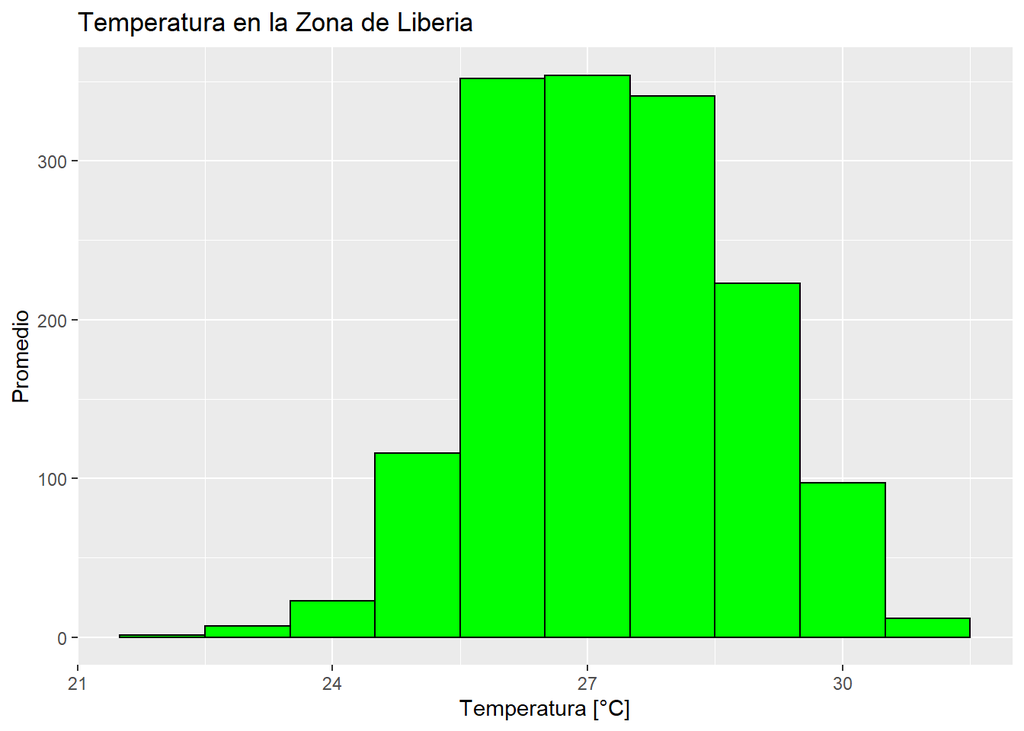

```r
ggplot(inp1) +
  geom_histogram(
    aes(x = Temperatura..Celsius.), bins = 6,
    binwidth = 1,
    color = "black",
    fill = "green"
  ) +
  ggtitle("Temperatura en la Zona de Liberia") +
  xlab("Temperatura [°C]") +
  ylab("Promedio")
```

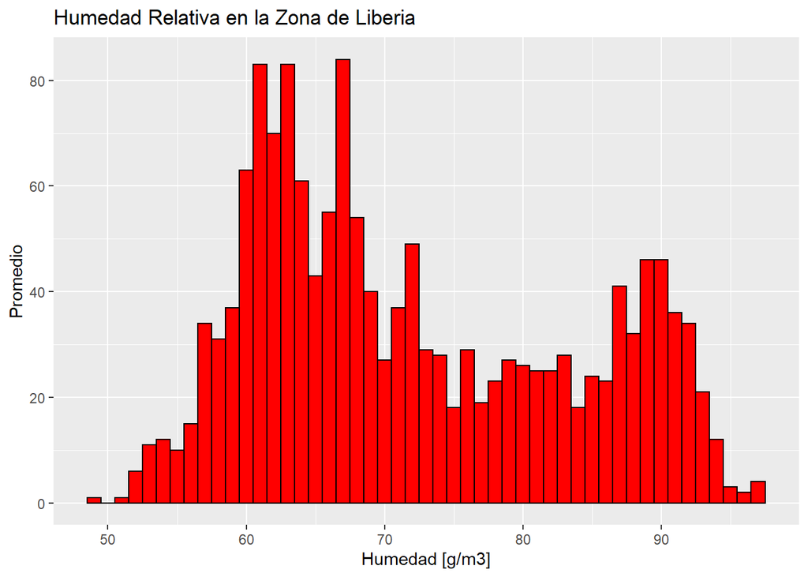

```r
ggplot(inp1) +
  geom_histogram(
    aes(x = HumedadRelativa....), bins = 4,
    binwidth = 1,
    color = "black",
    fill = "red"
  ) +
  ggtitle("Humedad Relativa en la Zona de Liberia") +
  xlab("Humedad [g/m3]") +
  ylab("Promedio")
```

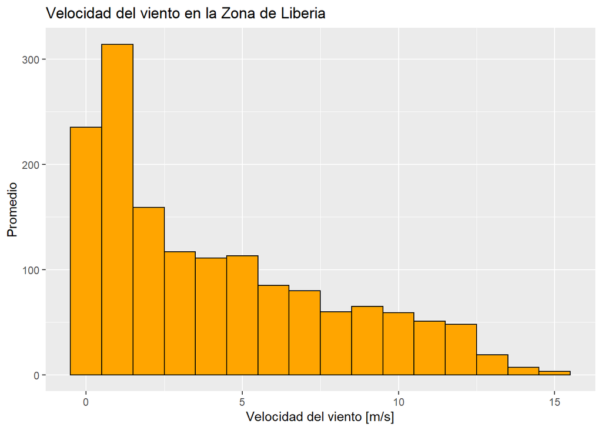

```r
ggplot(inp1) +
  geom_histogram(
    aes(x = VelocidadViento..m.s.),bins = 6,
    binwidth = 1,
    color = "black",
    fill = "orange"
  ) +
  ggtitle("Velocidad del viento en la Zona de Liberia") +
  xlab("Velocidad del viento [m/s]") +
  ylab("Promedio")
```

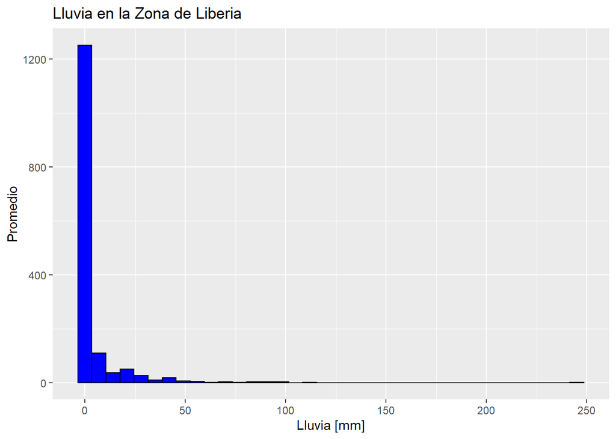

```r
ggplot(inp1) +
  geom_histogram(
    aes(x = Lluvia..mm.),bins = 4,
    binwidth = 7,
    color = "black",
    fill = "blue"
  ) +
  ggtitle("Lluvia en la Zona de Liberia") +
  xlab("Lluvia [mm]") +
  ylab("Promedio")
```

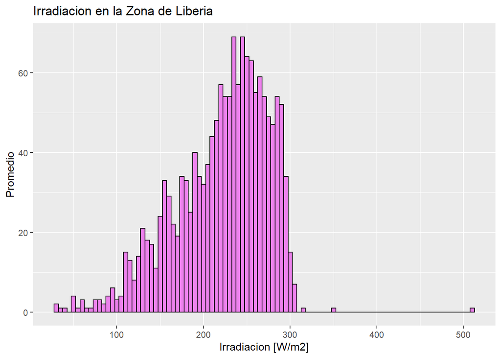

```r
ggplot(inp1) +
  geom_histogram(
    aes(x = Irradiacion..W.m2.),bins = 4,
    binwidth = 5,
    color = "black",
    fill = "violet"
  ) +
  ggtitle("Irradiacion en la Zona de Liberia") +
  xlab("Irradiacion [W/m2]") +
  ylab("Promedio")
```

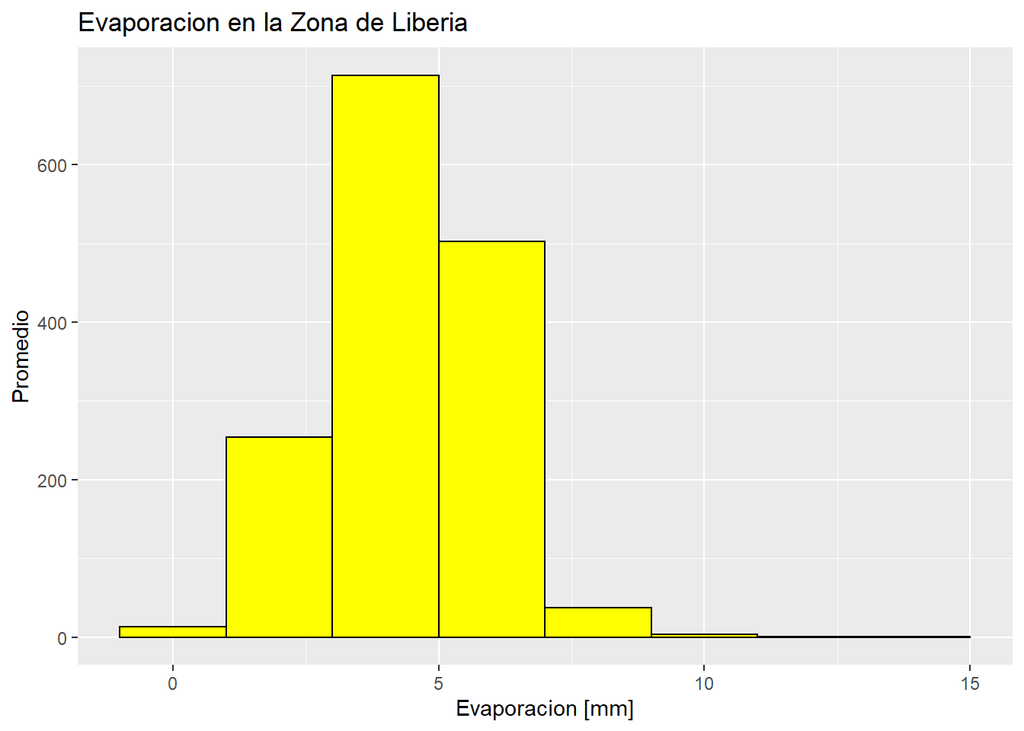

```r
ggplot(inp1) +
  geom_histogram(
    aes(x = EvapoTranspiracion..mm.),bins = 4,
    binwidth = 2,
    color = "black",
    fill = "yellow"
  ) +
  ggtitle("Evaporacion en la Zona de Liberia") +
  xlab("Evaporacion [mm]") +
  ylab("Promedio")
```

## Promedio mensual de la climatología de Liberia

Aquí se representan los datos mensuales, de las variables dadas para el analisis

### Promedio Mensual del año 2015 para la zona de Liberia.

Aquí encontraran los promedios mensuales del año 2015 correspondientes a las variables: Temperatura, Humedad, Velocidad del viento, Irradiacion, y la suma mensual de las variables Lluvia y Evaporacion.

```r
Promedioclimatologicos2015 <- mutate(Datos2015, Date = as.Date(Datos2015$Date, format("%d,%m,%y"))) %>%
  group_by(Datos2015$Date, format(Datos2015$Date, format("%m")))
```

```
##   Temperatura  Humedad Velocidad Lluvia Irradiacion Evaporacion
## 1    27.53839 65.00484  6.134194   0.25    234.0332      154.64
## 2    27.76000 61.82536  5.147143   0.00    255.7768      162.70
## 3    28.35452 58.17742  8.675484   2.83    270.3542      201.33
## 4    29.26300 61.82767  7.221667   1.52    264.6430      180.05
## 5    29.38968 62.70484  6.748387   3.80    254.5006      177.80
## 6    28.35900 75.76833  5.690667 126.41    214.8303      146.39
```

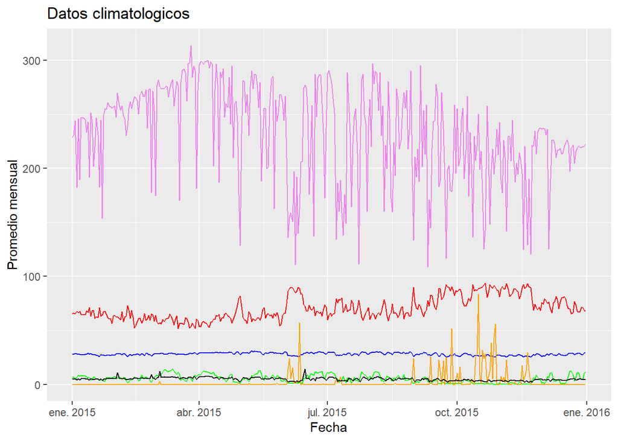

### Promedio Mensual año 2016 para la zona de Liberia.

Aquí encontraran los promedios mensuales del año 2016 correspondientes a las variables: Temperatura, Humedad, Velocidad del viento, Irradiacion, y la suma mensual de las variables Lluvia y Evaporacion.

```r
Promedioclimatologicos2016 <- mutate(Datos2016, Date = as.Date(Datos2016$Date, format("%d,%m,%y"))) %>%
  group_by(Datos2016$Date, format(Datos2016$Date, format("%m")))
```

```
##   Temperatura  Humedad Velocidad Lluvia Irradiacion Evaporacion
## 1    27.39355 66.39613  6.207097   0.00    233.2755      157.66
## 2    28.07276 61.37103  9.103103   0.00    255.6017      173.31
## 3    29.38194 58.90419  5.984839   0.50    266.3484      190.82
## 4    29.69700 62.36433  5.222000  43.91    246.6033      167.33
## 5    28.43935 75.79452  2.781613 187.39    223.5216      138.59
## 6    26.55433 85.53100  1.864000 279.26    197.0427      102.34
```

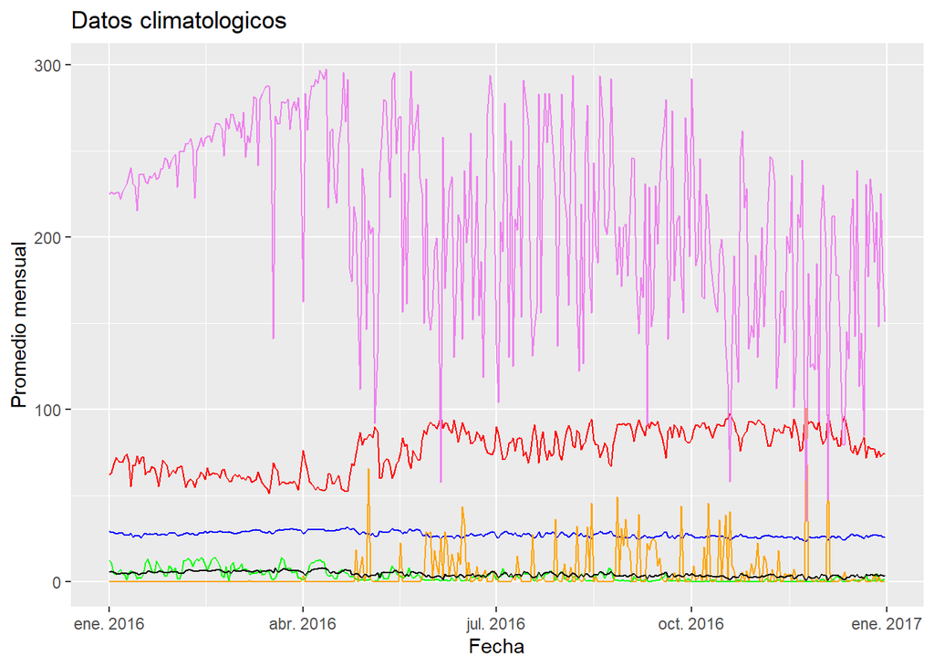

### Promedio Mensual del año 2017 en la Zona de Liberia

Aquí encontraran los promedios mensuales del año 2017 correspondientes a las variables: Temperatura, Humedad, Velocidad del viento, Irradiacion, y la suma mensual de las variables Lluvia y Evaporacion.

```r
Promedioclimatologicos2017 <- mutate(Datos2017, Date = as.Date(Datos2017$Date, format("%d,%m,%y"))) %>%
  group_by(Datos2017$Date, format(Datos2017$Date, format("%m")))
```

```
##   Temperatura  Humedad Velocidad Lluvia Irradiacion Evaporacion
## 1    26.31387 71.58968 1.9354839   7.10    226.1126      129.42
## 2    27.14714 65.85643 0.2428571   0.00    255.3168      126.38
## 3    28.26065 61.44129 4.9632258   5.82    274.5858      175.93
## 4    28.90767 67.48233 5.3060000 107.66    258.2047      163.79
## 5    26.64710 87.45774 1.2141935 414.92    191.9590      101.16
## 6    26.29700 88.54800 1.1966667 225.96    170.6980       87.16
```

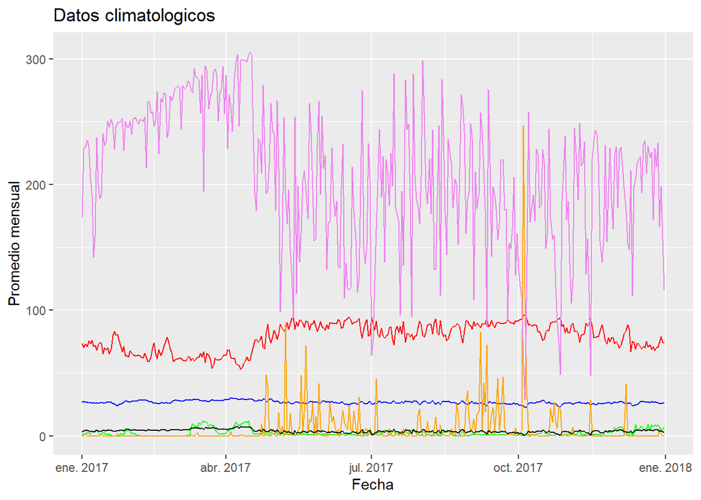

### Promedio Mensual del año 2018 en la Zona de Liberia

Aquí encontraran los promedios mensuales del año 2018 correspondientes a las variables: Temperatura, Humedad, Velocidad del viento, Irradiacion, y la suma mensual de las variables Lluvia y Evaporacion.

```r
Promedioclimatologicos2018 <- mutate(Datos2018, Date = as.Date(Datos2018$Date, format("%d,%m,%y"))) %>%
  group_by(Datos2018$Date, format(Datos2018$Date, format("%m")))
```

```
##   Temperatura  Humedad  Velocidad Lluvia Irradiacion Evaporacion
## 1    26.72071 68.40500  7.8760714   4.80    231.6989      140.20
## 2    27.37154 63.00077 10.0557692   2.79    265.0827      156.76
## 3    28.21304 58.67087  9.0156522   0.00    286.8957      150.58
## 4    28.53391 63.35870  5.4265217   0.25    284.8513      129.57
## 5    26.67192 67.53692  0.8573077 357.26    203.9769       91.52
## 6    26.57467 63.61867  2.0993333 241.24    202.4740      108.59
```

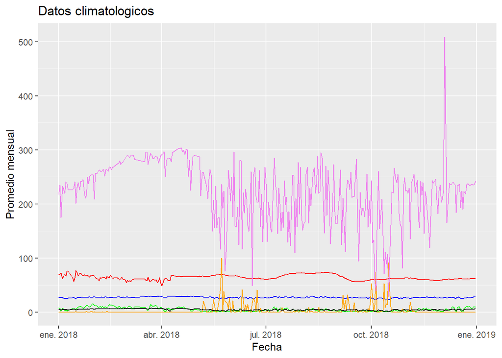

### Promedio Mensual del año 2019 en la Zona de Liberia

Aquí encontraran los promedios mensuales del año 2019 correspondientes a las variables: Temperatura, Humedad, Velocidad del viento, Irradiacion, y la suma mensual de las variables Lluvia y Evaporacion.

```r
Promedioclimatologicos2019 <- mutate(Datos2019, Date = as.Date(Datos2019$Date, format("%d,%m,%y"))) %>%
  group_by(Datos2019$Date, format(Datos2019$Date, format("%m")))
```

```
##   Temperatura  Humedad Velocidad Lluvia Irradiacion Evaporacion
## 1    27.29065 65.47742  8.690968   6.34    242.0971      170.94
## 2    27.97071 67.22929  7.655714   0.00    265.5768      166.82
## 3    28.52968 63.50935  8.848710   0.00    269.9239      196.48
```

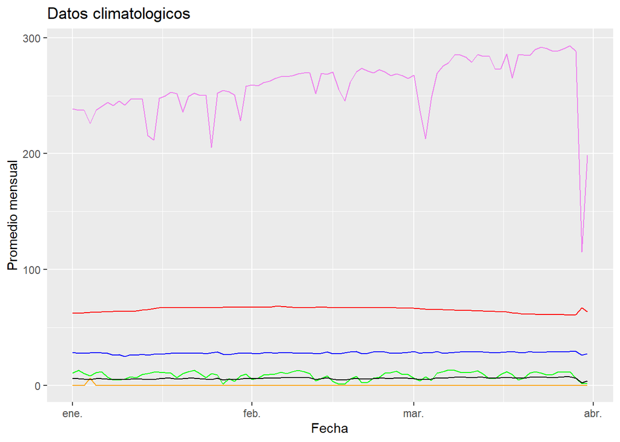

Aqui se presentan una serie de graficos correspondientes a la temperatura,humedad, Velocidad del viento, lluvia, irradiacion y Evaporacion de la Zona de Liberia

### Grafico de Dispersion

Aqui se presentan una serie de graficos correspondientes a la temperatura,humedad, Velocidad del viento, lluvia, irradiacion y Evaporacion de la Zona de Liberia y su respectiva relacion.

#### Relacion entre la Humedad y la Temperatura de la Zona de Liberia.

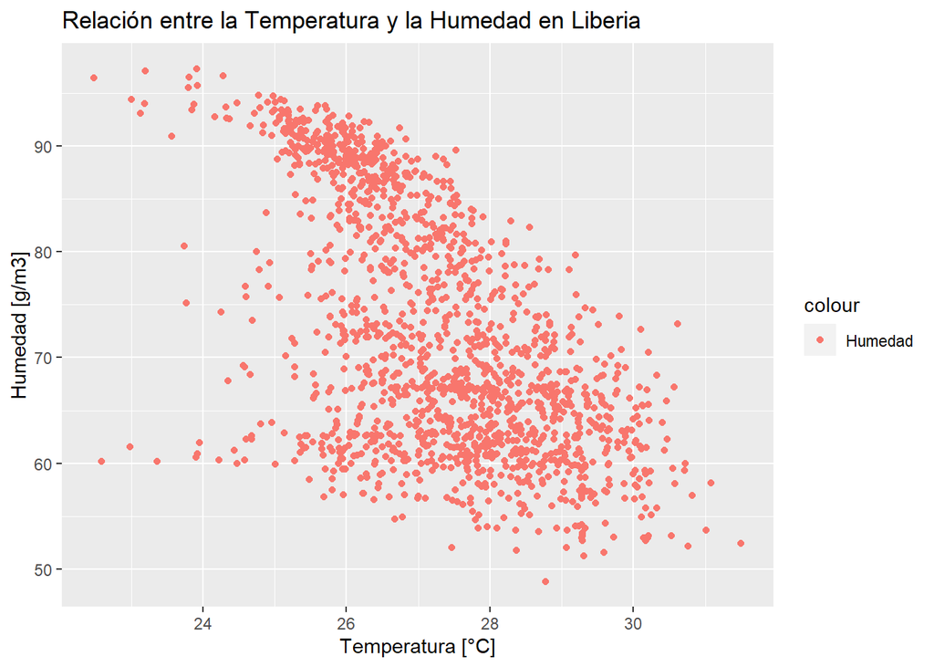

#### Relación entre la Humedad con la Velocidad del viento en la Zona de Liberia.

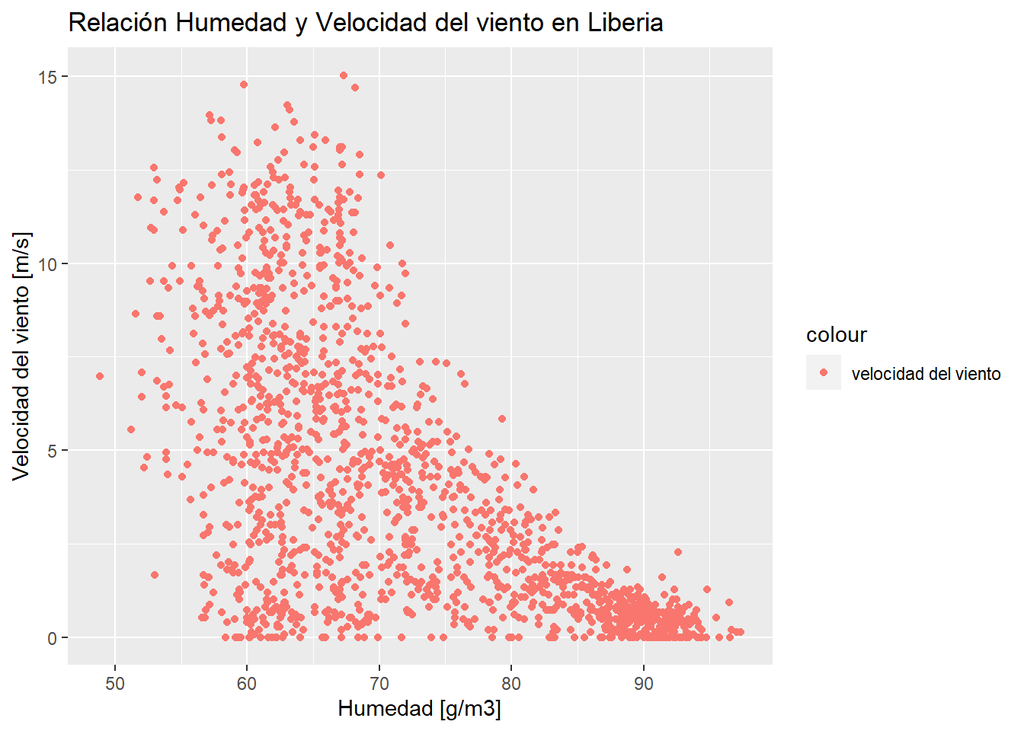

#### Relacion entre Velocidad del viento y la Lluvia en la Zona de Liberia.

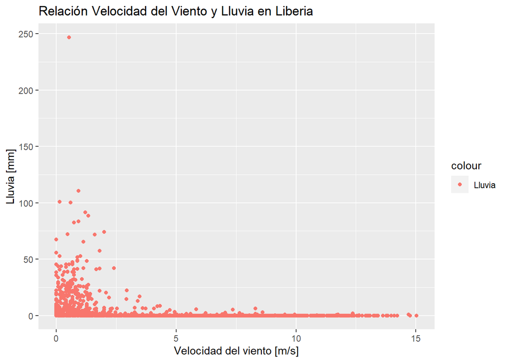

#### Relacion entre la Lluvia y la Irradiacion en la Zona de Liberia,

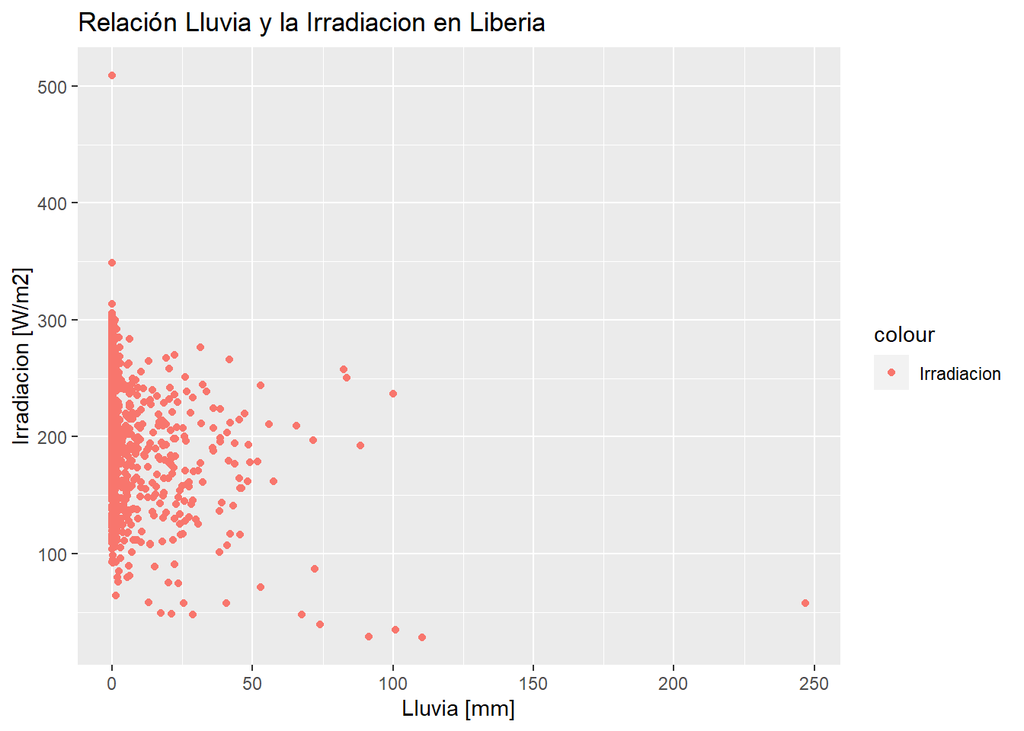

#### Relacion entre la Irradiacion y Evaporacion en la Zona de Liberia.

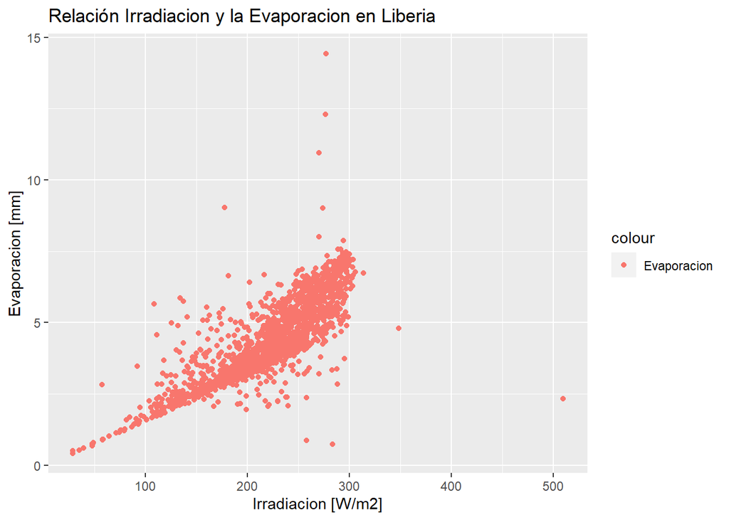

#### Relacion entre la Evaporacion y la Temperatura en la Zona de Liberia,

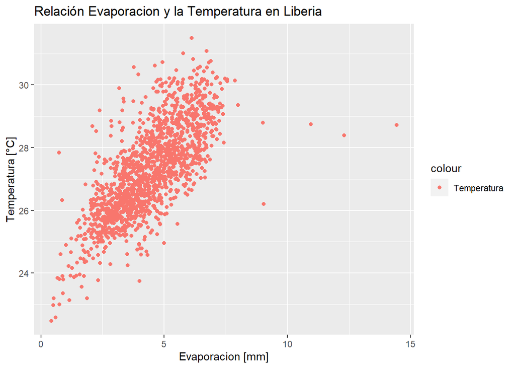